class: inverse, middle, center

# Coding in the console

.pull-left[ When you first open R, the console should be empty.

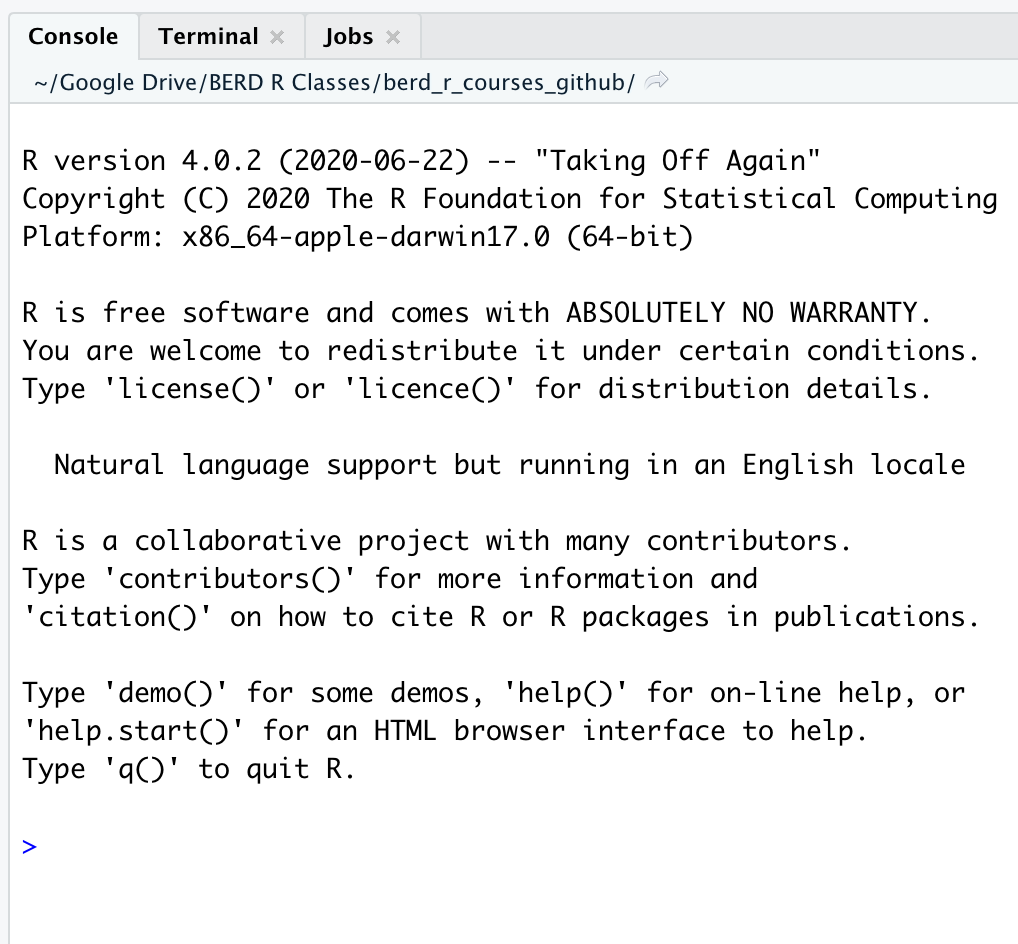

]

.pull-right[ **Typing and executing code in the console** * Type code in the console (blue text) * Press **return** to execute the code * Output shown below in black

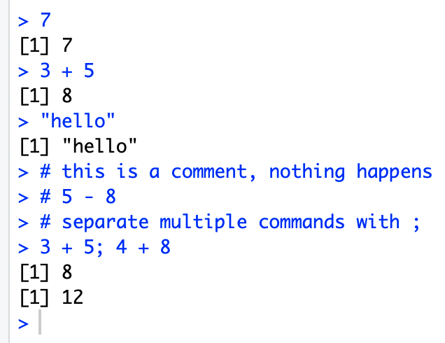

]

# Math calculations using R

.pull-left[

```r
> 10^2
```

```
[1] 100
```

```r
> 3 ^ 7
```

```
[1] 2187
```

```r
> 6/9
```

```
[1] 0.6666667
```

```r
> 9-43
```

```
[1] -34
```

]

–

.pull-right[ * Rules for order of operations are followed * Spaces between numbers and characters are ignored

```r
> 4^3-2* 7+9 /2
```

```
[1] 54.5
```

The equation above is computed as
$$4^3 − (2 \cdot 7) + \frac{9}{2}$$
]

# Variables

Variables are used to store data, figures, model output, etc. .pull-left[ * Can assign a variable using either `=` or `<-` - Using `<-` is preferable - type name of variable to print

Assign just one value:

```r
> x = 5
> x
```

```
[1] 5
```

```r
> x <- 5
> x
```

```
[1] 5
```

]

–

.pull-right[ Assign a **vector** of values: * Consecutive integers using `:`

```r
> a <- 3:10
> a
```

```
[1]  3  4  5  6  7  8  9 10
```

- **Concatenate** a string of numbers

```r
> b <- c(5, 12, 2, 100, 8)
> b
```

```
[1]   5  12   2 100   8
```

]

# We can do math with variables

.pull-left[ Math using variables with just one value

```r
> x <- 5
> x
```

```
[1] 5
```

```r
> x + 3
```

```
[1] 8
```

```r
> y <- x^2
> y
```

```
[1] 25
```

]

–

.pull-right[ Math on vectors of values:  
**element-wise** computation

```r
> a <- 3:6
> a
```

```
[1] 3 4 5 6
```

```r
> a+2; a*3
```

```
[1] 5 6 7 8
```

```
[1]  9 12 15 18
```

```r
> a*a
```

```
[1]  9 16 25 36
```

]

# Variables can include text (characters)

```r
> hi <- "hello"
> hi
```

```
[1] "hello"
```

```r
> greetings <- c("Guten Tag", "Hola", hi)
> greetings
```

```
[1] "Guten Tag" "Hola"      "hello"
```

# Using functions

- `mean()` is an example of a function
- functions have “arguments” that are specified within the `()`
- `?mean` in console will show help for `mean()`

.pull-left[ Arguments specified by name:

```r
> mean(x = 1:4)
```

```
[1] 2.5
```

```r
> seq(from = 1, to = 12, by = 3)
```

```
[1]  1  4  7 10
```

```r
> seq(by = 3, to = 12, from = 1)
```

```
[1]  1  4  7 10
```

] .pull-right[ Arguments not specified, but listed in order:

```r
> mean(1:4)
```

```
[1] 2.5
```

```r
> seq(1,12,3)
```

```
[1]  1  4  7 10
```

]

# Missing values

Missing values are denoted as `NA` and are handled differently depending on the operation. There are special functions for `NA` (i.e. `is.na()`, `na.omit()`). .pull-left[

```r
> x <- c(1, 2, NA, 5)
> is.na(x)
```

```
[1] FALSE FALSE  TRUE FALSE
```

```r
> mean(x)
```

```
[1] NA
```

```r
> mean(x, na.rm=TRUE)
```

```
[1] 2.666667
```

] .pull-right[

```r
> x <- c("a", "a", NA, "b")
> table(x)
```

```
x
a b
2 1
```

```r
> table(x, useNA = "always")
```

```
x
   a    b <NA>
   2    1    1
```

]

# Common console errors (1/2)

**Incomplete commands**

.pull-left[ * When the console is waiting for a new command, the prompt line begins with `>` + If the console prompt is `+`, then a previous command is incomplete + You can finish typing the command in the console window]

.pull-right[ Example:

```r
> 3 + (2*6
+ )
```

```
[1] 15
```

]

# Common console errors (2/2)

**Object is not found**

- This happens when text is entered for a non-existent variable (object)

Example:

```r
> hello
```

```
Error in eval(expr, envir, enclos): object 'hello' not found
```

- Can be due to missing quotes

```r
> install.packages(dplyr) # need install.packages("dplyr")
```

```
Error in install.packages(dplyr): object 'dplyr' not found
```